# ggplot-sample code

```r
library(ggplot2)
```

**Bigpicture** The main difference is that, unlike base graphics, ggplot works with dataframes and not individual vectors. All the data needed to make the plot is typically contained within the dataframe supplied to the ggplot() The second main difference is that you can keep enhancing the plot by adding more layers to an existing plot.

Structure: The principal components of every plot can be defined as follows: data: is a data frame Aesthetics: is used to indicate x and y variables. It can also be used to control the color, the size or the shape of points, the height of bars, etc….. Geometry: corresponds to the type of graphics (histogram, box plot, line plot, density plot, dot plot, ….)

```r
library(ggplot2)
```

```r
print(mpg)
```

```
## # A tibble: 234 x 11
##    manufacturer model    displ  year   cyl trans   drv     cty   hwy fl
##    <chr>        <chr>    <dbl> <int> <int> <chr>   <chr> <int> <int> <chr>
##  1 audi         a4         1.8  1999     4 auto(l… f        18    29 p
##  2 audi         a4         1.8  1999     4 manual… f        21    29 p
##  3 audi         a4         2    2008     4 manual… f        20    31 p
##  4 audi         a4         2    2008     4 auto(a… f        21    30 p
##  5 audi         a4         2.8  1999     6 auto(l… f        16    26 p
##  6 audi         a4         2.8  1999     6 manual… f        18    26 p
##  7 audi         a4         3.1  2008     6 auto(a… f        18    27 p
##  8 audi         a4 quat…   1.8  1999     4 manual… 4        18    26 p
##  9 audi         a4 quat…   1.8  1999     4 auto(l… 4        16    25 p
## 10 audi         a4 quat…   2    2008     4 manual… 4        20    28 p
## # ... with 224 more rows, and 1 more variable: class <chr>
```

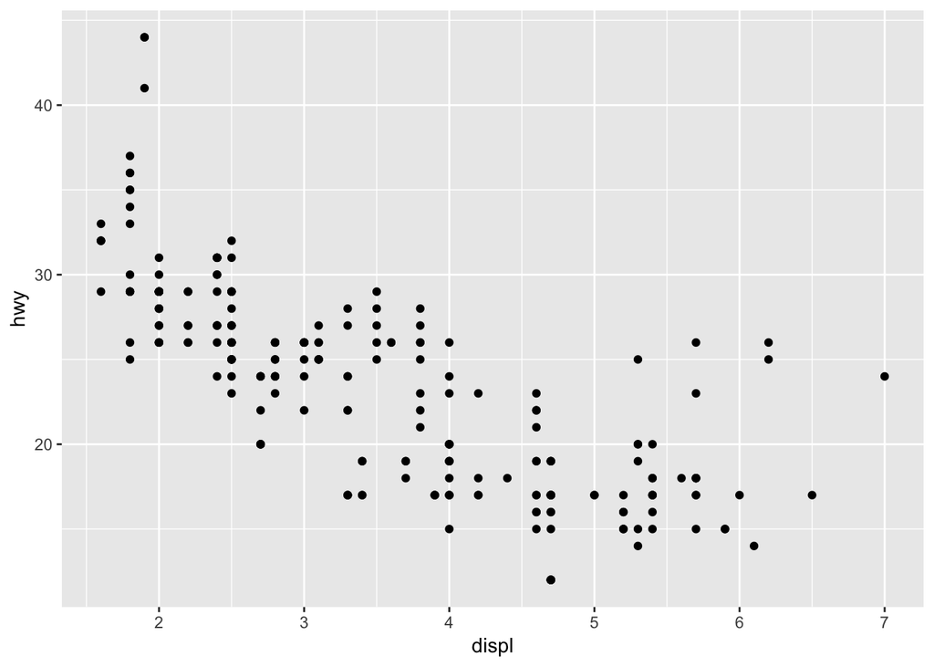

```r
# With ggplot2, you begin a plot with the function ggplot().
# ggplot() creates a coordinate system that you can add layers to.
# The first argument of ggplot() is the dataset to use in the graph.
# So ggplot(data = mpg) creates an empty graph.
# The function geom_point() adds a layer of points to your plot, which creates a scatterplot.
# ggplot2 comes with many geom functions that each add a different type of layer to a plot.
# Each geom function in ggplot2 takes a mapping argument. This defines how variables in your dataset are mapped to visual properties.
# The mapping argument is always paired with aes(), and the x and y arguments of aes()
# specify which variables to map to the x and y axes.

#ggplot(data = <DATA>) +
#  <GEOM_FUNCTION>(mapping = aes(<MAPPINGS>))
p <- ggplot(data = mpg) +
  geom_point(mapping = aes(x = displ, y = hwy))
print(p)
```

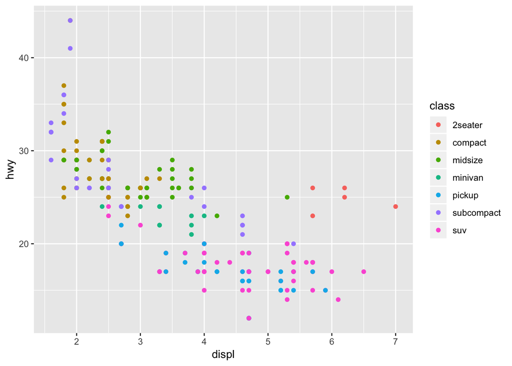

```r
p <- ggplot(data = mpg) +
  geom_point(mapping = aes(x = displ, y = hwy, color = class))
print(p)
```

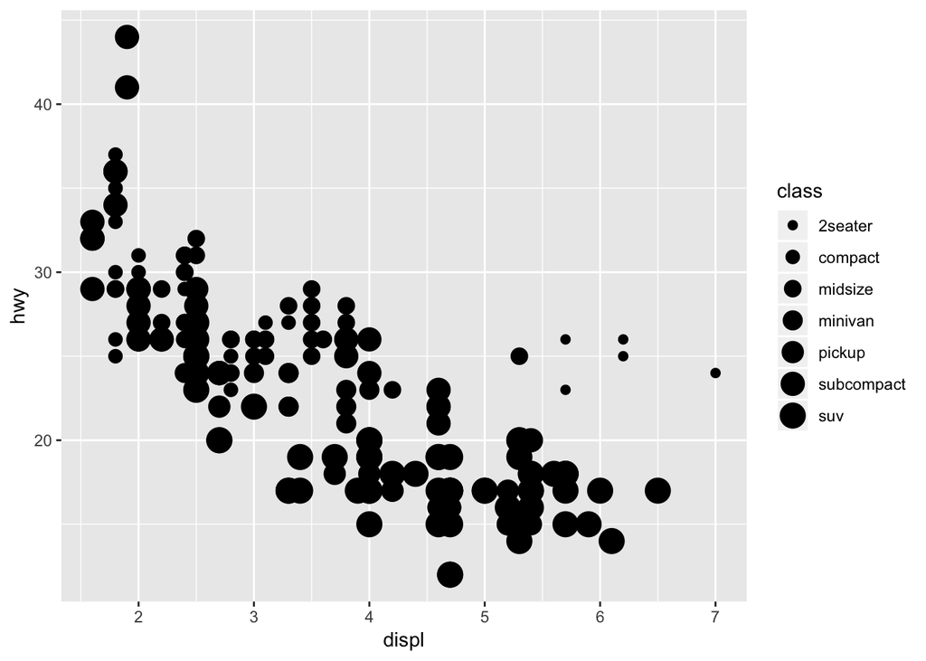

```r
p <- ggplot(data = mpg) +
  geom_point(mapping = aes(x = displ, y = hwy, size = class))
print(p)
```

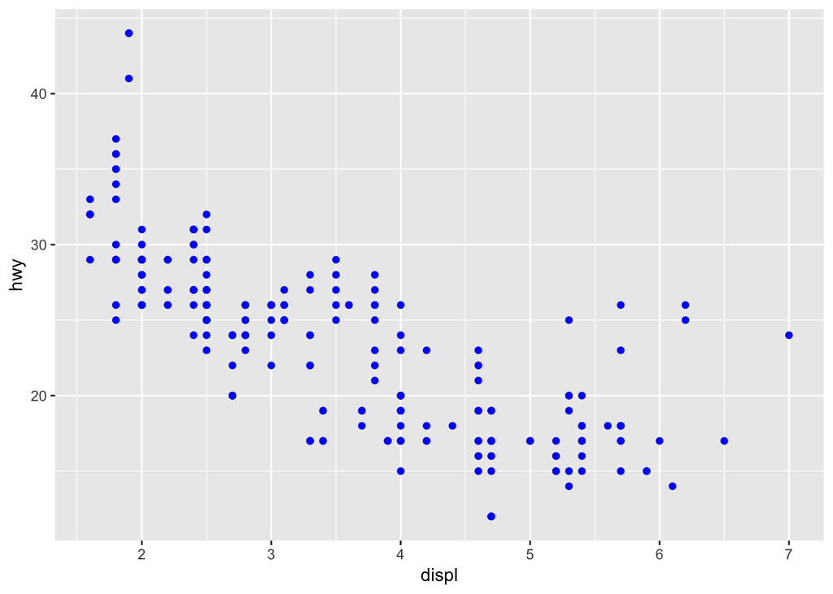

```r
#to make all points coloured blue
p <- ggplot(data = mpg) +
  geom_point(mapping = aes(x = displ, y = hwy), color = "blue")
print(p)
```

```r
#Example case where we want to fit a regression line- fit gives, regression fit
ggplotReg <- function(fit){
  ggplot(fit$model, aes_string(x=names(fit$model)[2], y=names(fit$model)[1])) +
    geom_point() +
    stat_smooth(method = "lm",col="red") +
    labs(title = paste("Adj R2 = ",signif(summary(fit)$adj.r.squared, 4),
                       "Intercept = ",signif(fit$coef[[1]],4),
                       "Slope = ",signif(fit$coef[[2]],4),
                       "P = ",signif(summary(fit)$coef[2,4], 4)))
}
```

**Different types of plots** Reference: http://r-statistics.co/Top50-Ggplot2-Visualizations-MasterList-R-Code.html

**1. correlation**

Plots for determining how well correlated two variables are

**1.1 Scatterplot**

```r
options(scipen=999)  #turn off scientific notation (e.g. 1e=48)
theme_set(theme_bw()) #pre-set the bw theme, decides non-data display
data("midwest",package = "ggplot2")
head(midwest)
```

```
## # A tibble: 6 x 28
##     PID county    state  area poptotal popdensity popwhite popblack
##   <int> <chr>     <chr> <dbl>    <int>      <dbl>    <int>    <int>
## 1   561 ADAMS     IL    0.052    66090      1271.    63917     1702
## 2   562 ALEXANDER IL    0.014    10626       759      7054     3496
## 3   563 BOND      IL    0.022    14991       681.    14477      429
## 4   564 BOONE     IL    0.017    30806      1812.    29344      127
## 5   565 BROWN     IL    0.018     5836       324.     5264      547
## 6   566 BUREAU    IL    0.05     35688       714.    35157       50
## # ... with 20 more variables: popamerindian <int>, popasian <int>,
## #   popother <int>, percwhite <dbl>, percblack <dbl>, percamerindan <dbl>,
## #   percasian <dbl>, percother <dbl>, popadults <int>, perchsd <dbl>,
## #   percollege <dbl>, percprof <dbl>, poppovertyknown <int>,
## #   percpovertyknown <dbl>, percbelowpoverty <dbl>,
## #   percchildbelowpovert <dbl>, percadultpoverty <dbl>,
## #   percelderlypoverty <dbl>, inmetro <int>, category <chr>
```

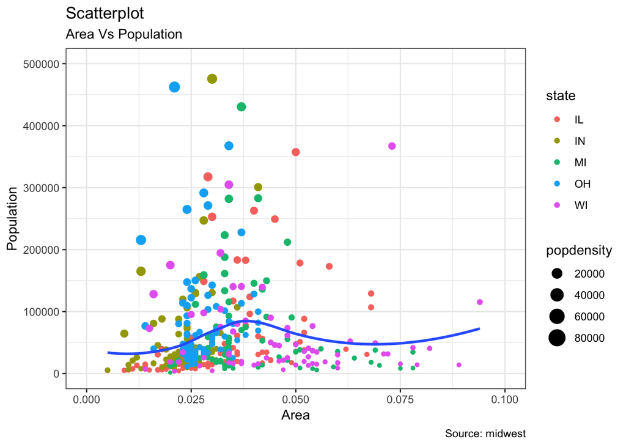

```r
#X-axis: area,
#y-axis: total population
#the points- coloured according to state,and size of points gives population density
#fit a smoothing line-use loess method, do not show confidence intervals around the line
#xlim and ylim will set the limits of values across X-axis and Y-axis
#labs argument will give labels
gg <- ggplot(midwest, aes(x=area,y=poptotal)) +
      geom_point(aes(col=state,size=popdensity)) +
      geom_smooth(method="loess", se=F) +
      xlim(c(0, 0.1)) +
      ylim(c(0, 500000)) +
      labs(subtitle="Area Vs Population",
            y="Population",
            x="Area",
            title="Scatterplot",
            caption = "Source: midwest")

print(gg)
```

**1.2 Scatterplot with encircling**

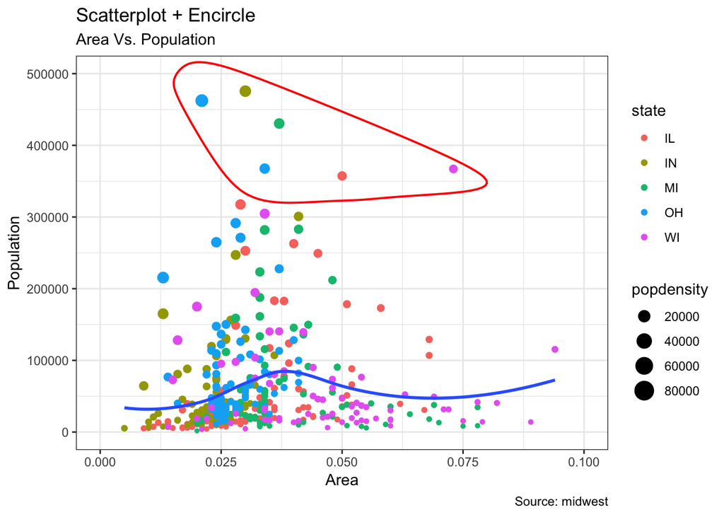

```r
library(ggalt) #library for geom_encircle

#Need to select the data subset which should be encircled, midwest_select below
#represent the data that needs to be encircled.
midwest_select <- midwest[midwest$poptotal > 350000 &
                            midwest$poptotal <= 500000 &
                            midwest$area > 0.01 &
                            midwest$area < 0.1, ]
ggplot(midwest, aes(x=area, y=poptotal)) +
  geom_point(aes(col=state, size=popdensity)) +   # draw points
  geom_smooth(method="loess", se=F) +
  xlim(c(0, 0.1)) +
  ylim(c(0, 500000)) +   # draw smoothing line
  geom_encircle(aes(x=area, y=poptotal),
                data=midwest_select,
                color="red",
                size=2,
                expand=0.08) +   # encircle
  labs(subtitle="Area Vs. Population",
       y="Population",
       x="Area",
       title="Scatterplot + Encircle",
       caption="Source: midwest")
```

**1.2 Scatterplot where there are many overlapping points**

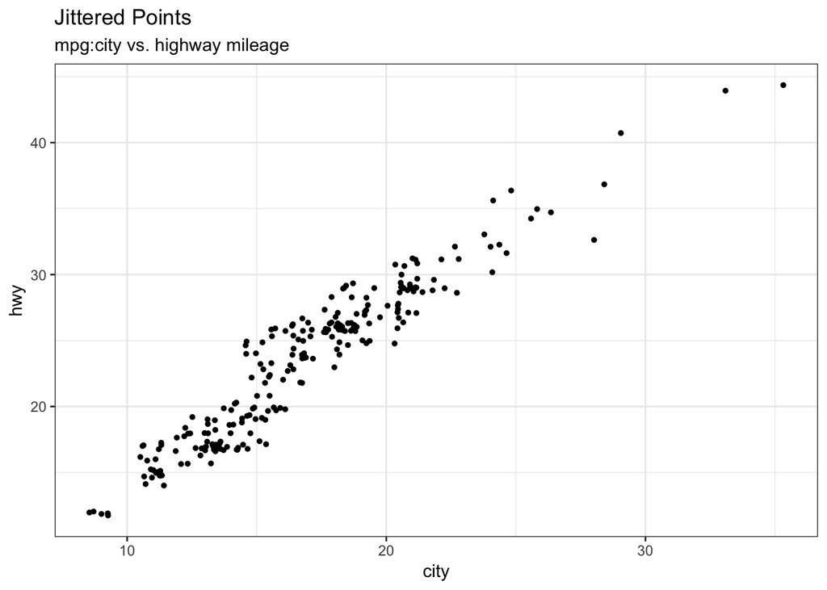

```r
# option 1- add jitter ***#
#if there are a lot of overlapping points, jitterplot will introduce some jitter to the data
data(mpg,package="ggplot2")
theme_set(theme_bw())
ggplot(mpg,aes(cty,hwy)) +
  geom_jitter(width=0.5,size=1) +
  labs(subtitle = "mpg:city vs. highway mileage",
       y="hwy",
       x="city",
       title = "Jittered Points")
```

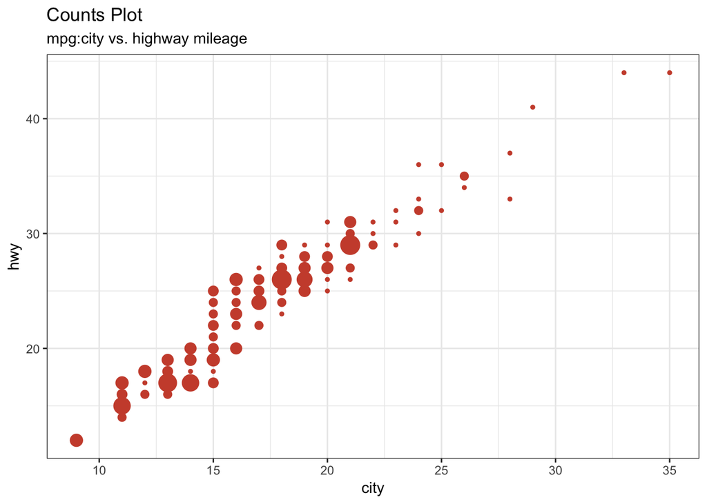

```r
# option 2- counts chart; wherever there is more overlap, the size of the circle gets bigger ***#
data(mpg, package="ggplot2")
theme_set(theme_bw())
ggplot(mpg,aes(x=cty,y=hwy)) +
  geom_count(col="tomato3",show.legend = F) +
  labs(subtitle = "mpg:city vs. highway mileage",
       y="hwy",
       x="city",
       title = "Counts Plot")
```

**1.3 Bubble chart**

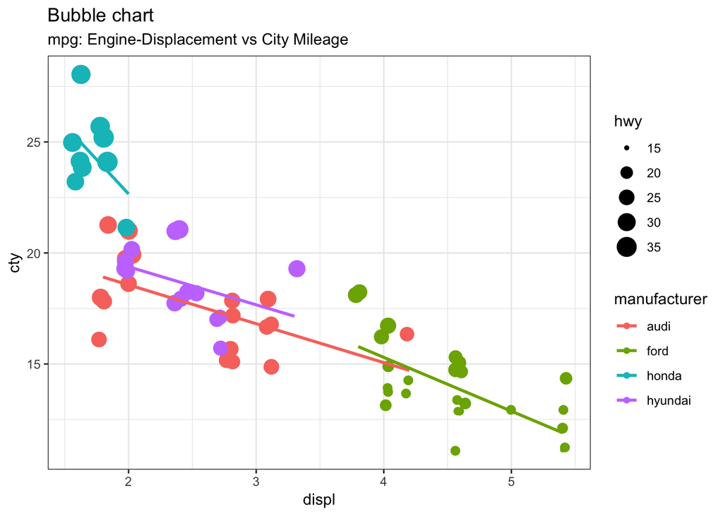

```r
#Bubble chart serves well if you want to understand relationship within the underlying groups based on:
# A Categorical variable (by changing the color) and
# Another continuous variable (by changing the size of points).

mpg_select <- mpg[mpg$manufacturer %in% c("audi", "ford", "honda", "hyundai"), ]
g <- ggplot(mpg_select, aes(displ, cty)) +
  labs(subtitle="mpg: Engine-Displacement vs City Mileage",
       title="Bubble chart")
g + geom_jitter(aes(col=manufacturer, size=hwy)) +
  geom_smooth(aes(col=manufacturer), method="lm", se=F)
```

**1.4 Correlation of multiple continuous variables present in the same dataframe. (correlation matrix)**

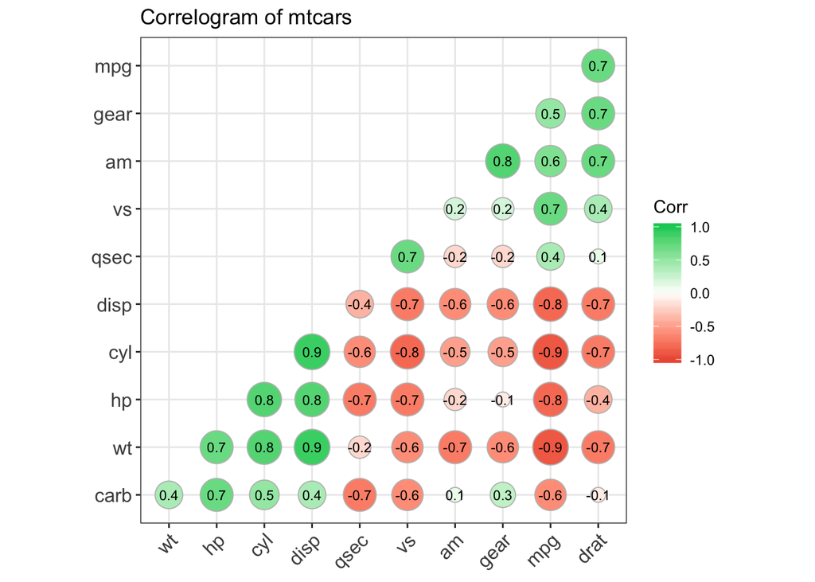

```r
library(ggcorrplot)
data(mtcars)
corr <- round(cor(mtcars), 1)
ggcorrplot(corr, hc.order = TRUE,
           type = "lower",
           lab = TRUE,
           lab_size = 3,
           method = "circle",
           colors = c("tomato2","white","springgreen3"),
           title = "Correlogram of mtcars",
           ggtheme = theme_bw)
```

**2. Deviation** Compare variation in values between small number of items (or categories) with respect to a fixed reference. The below plot will show for a range of car brands, how far the mileage is above/below from the average

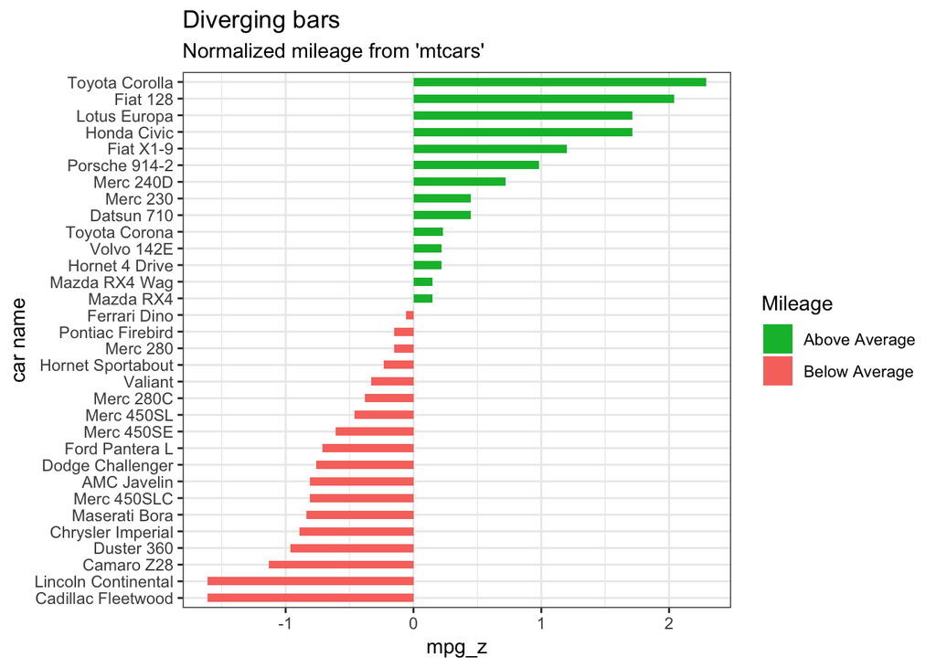

```r
data(mtcars)
mtcars$'car name' <- rownames(mtcars)  #create new column for car names
mtcars$mpg_z <- round((mtcars$mpg - mean(mtcars$mpg))/sd(mtcars$mpg),2) #normalized mpg
mtcars$mpg_type <- ifelse(mtcars$mpg_z < 0, "below","above") #above/below avg
mtcars <- mtcars[order(mtcars$mpg_z),] #sort
mtcars$'car name' <- factor(mtcars$'car name',levels = mtcars$`car name`)

ggplot(mtcars, aes(x=`car name`, y=mpg_z, label = mpg_z)) +
  geom_bar(stat = 'identity', aes(fill=mpg_type), width=0.5) +
  scale_fill_manual(name = "Mileage",
                    labels = c("Above Average", "Below Average"),
                    values = c("above" = "#00ba38","below"="#f8766d"))+
  labs(subtitle = "Normalized mileage from 'mtcars'",
       title = "Diverging bars") +
  coord_flip()
```

**2.1 Diverging lollipop chart** - same as above, except a different form of depiction

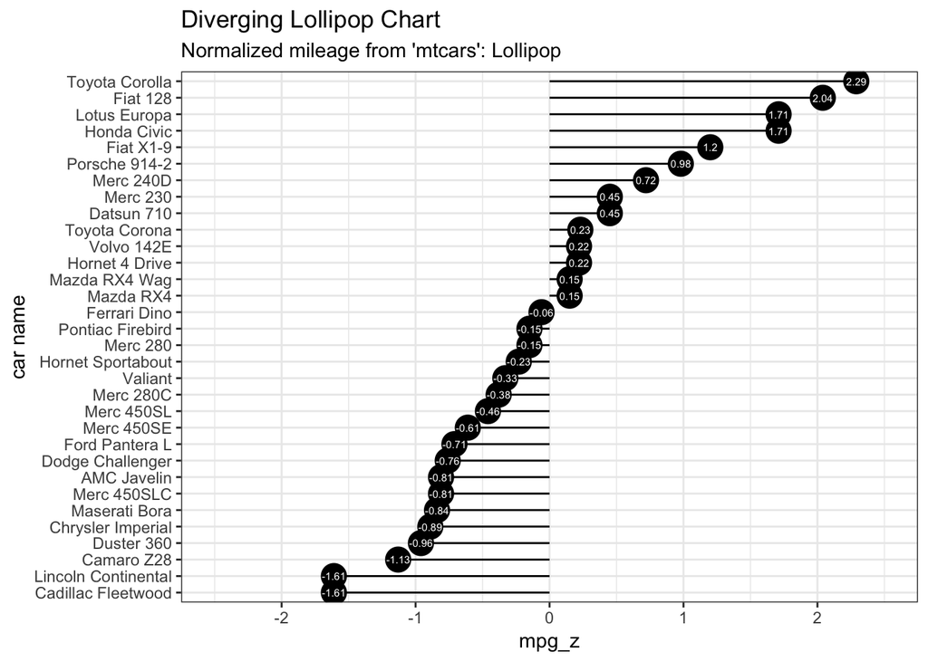

```r
ggplot(mtcars, aes(x=`car name`, y=mpg_z, label=mpg_z)) +
  geom_point(stat='identity', fill="black", size=6)  +
  geom_segment(aes(y = 0,
                   x = `car name`,
                   yend = mpg_z,
                   xend = `car name`),
               color = "black") +
  geom_text(color="white", size=2) +
  labs(title="Diverging Lollipop Chart",
       subtitle="Normalized mileage from 'mtcars': Lollipop") +
  ylim(-2.5, 2.5) +
  coord_flip()
```

**2.2 Diverging dot plot** - same as above, slightly different way of depicting

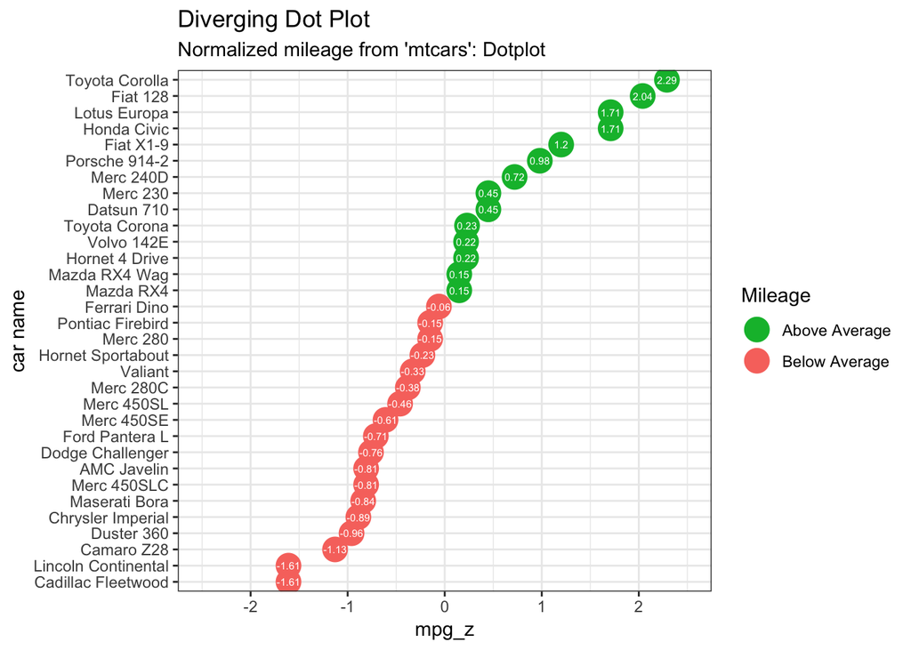

```r
ggplot(mtcars, aes(x=`car name`, y=mpg_z, label=mpg_z)) +
  geom_point(stat='identity', aes(col=mpg_type), size=6)  +
  scale_color_manual(name="Mileage",
                     labels = c("Above Average", "Below Average"),
                     values = c("above"="#00ba38", "below"="#f8766d")) +
  geom_text(color="white", size=2) +
  labs(title="Diverging Dot Plot",
       subtitle="Normalized mileage from 'mtcars': Dotplot") +
  ylim(-2.5, 2.5) +
  coord_flip()
```

**3. Area chart** Area charts are typically used to visualize how a particular metric (such as % returns from a stock) performed compared to a certain baseline. geom_area() implements this.

```r
library(quantmod)
```

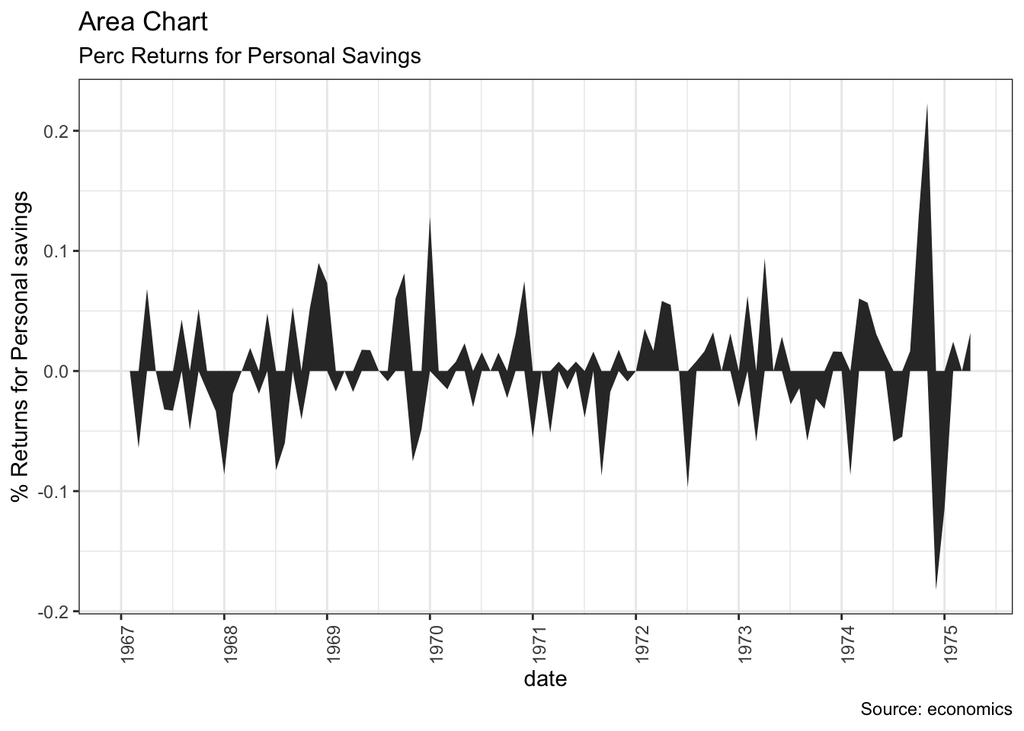

```r
data("economics", package = "ggplot2")

# Compute % Returns
economics$returns_perc <- c(0, diff(economics$psavert)/economics$psavert[-length(economics$psavert)])

# Create break points and labels for axis ticks
brks <- economics$date[seq(1, length(economics$date), 12)]
lbls <- lubridate::year(economics$date[seq(1, length(economics$date), 12)])

# Plot
ggplot(economics[1:100, ], aes(date, returns_perc)) +
  geom_area() +
  scale_x_date(breaks=brks, labels=lbls) +       #override default date scales
  theme(axis.text.x = element_text(angle=90)) +  #Not sure what this line does!
  labs(title="Area Chart",
       subtitle = "Perc Returns for Personal Savings",
       y="% Returns for Personal savings",
       caption="Source: economics")
```

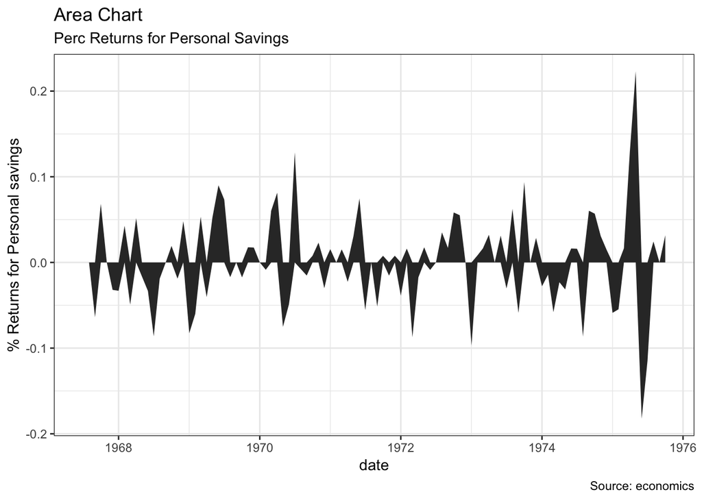

```r
ggplot(economics[1:100, ], aes(date, returns_perc)) +
  geom_area() +
  labs(title="Area Chart",
       subtitle = "Perc Returns for Personal Savings",
       y="% Returns for Personal savings",
       caption="Source: economics")
```